# Rapport d’Analyse — Enquête KAP Mpox

Résultats détaillés et visualisations interactives

11 mai 2026

[figure not shown]

# Rapport d’Analyse MPOX

Résultats KAP — Croix-Rouge Malagasy | mai 2026

# 1 Résumé exécutif

6679

Répondants

7

Régions

26/02/2026 → 18/03/2026

Période

Ce rapport présente les principaux résultats de l’enquête **Knowledge, Attitudes, and Practices (KAP)** relative au Mpox menée par la Croix-Rouge Malagasy. Les visualisations ci-dessous sont organisées par thème avec des descriptions et interprétations détaillées.

# 2 SECTION A — CONTEXTE DE L’ÉPIDÉMIE

## 2.1 A1. Connaissance du Mpox

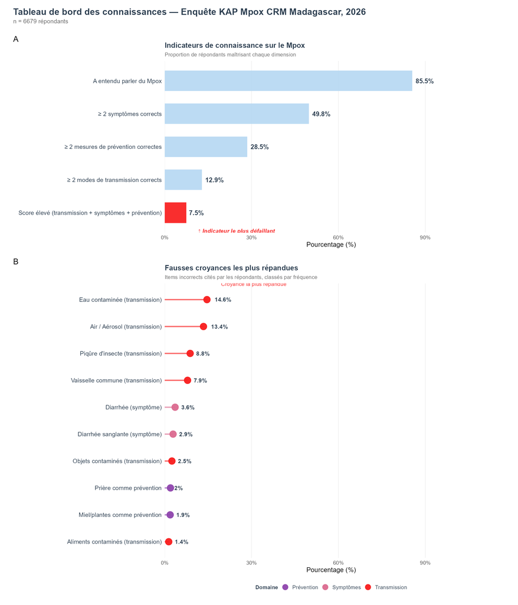

⬇️ Télécharger PNG

**Description :** Ce graphique présente le pourcentage de répondants ayant entendu parler du Mpox avant l’enquête. La mesure inclut tous les participants indépendamment de la profondeur de leur connaissance.

**Interprétation :** Un taux élevé de connaissance indique une bonne pénétration des messages de sensibilisation. Un taux plus faible suggère le besoin de campagnes de communication renforcées dans les zones ou populations ciblées.

## 2.2 A2. Présence du Mpox dans la communauté

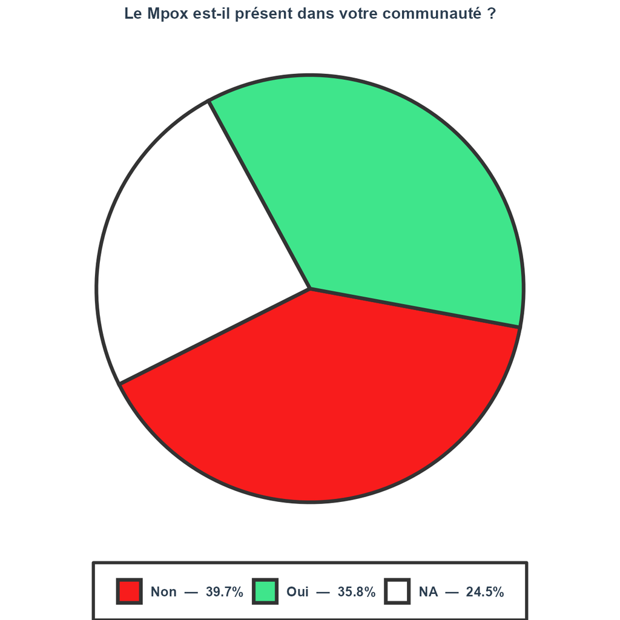

⬇️ Télécharger PNG

**Description :** Mesure la perception des répondants quant à la présence du Mpox dans leur communauté immédiate (village, quartier, district).

**Interprétation :** La perception du risque local est un indicateur clé du besoin de renforcer les mesures de santé publique. Elle influence aussi l’adoption de comportements préventifs.

# 3 SECTION B — FACTEURS DE RISQUE PERÇUS

## 3.1 B1. Facteurs de vulnérabilité identifiés

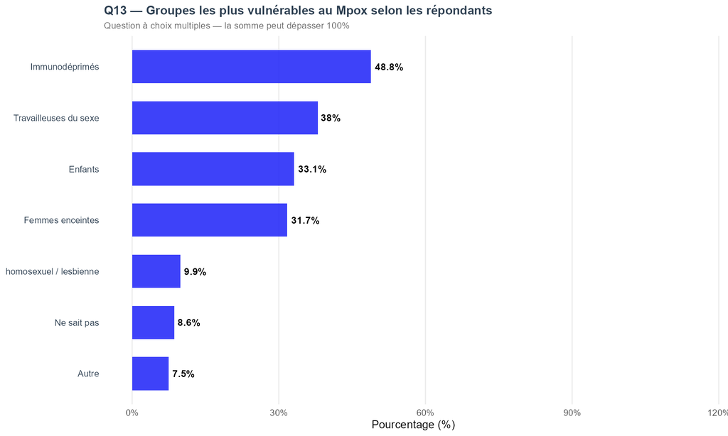

⬇️ Télécharger PNG

**Interprétation :** Identifie les groupes de population perçus comme les plus à risque. Aide à cibler les interventions de prévention et d’accès aux services de santé.

# 4 SECTION D — SOURCES D’INFORMATION

## 4.1 D1. Sources d’information utilisées

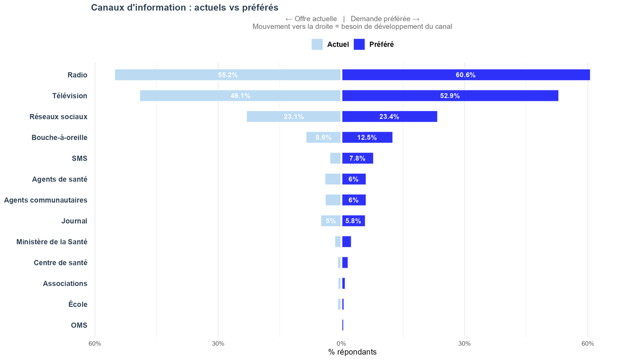

⬇️ Télécharger PNG

**Description :** Canaux par lesquels les répondants reçoivent des informations sur le Mpox (radio, TV, agents de santé, réseaux sociaux, bouche-à-oreille, etc.).

**Interprétation :** Oriente la stratégie de communication. Les sources dominantes sont les plus efficaces pour diffuser les messages de santé publique.

## 4.2 D4. Sources d’information fiables

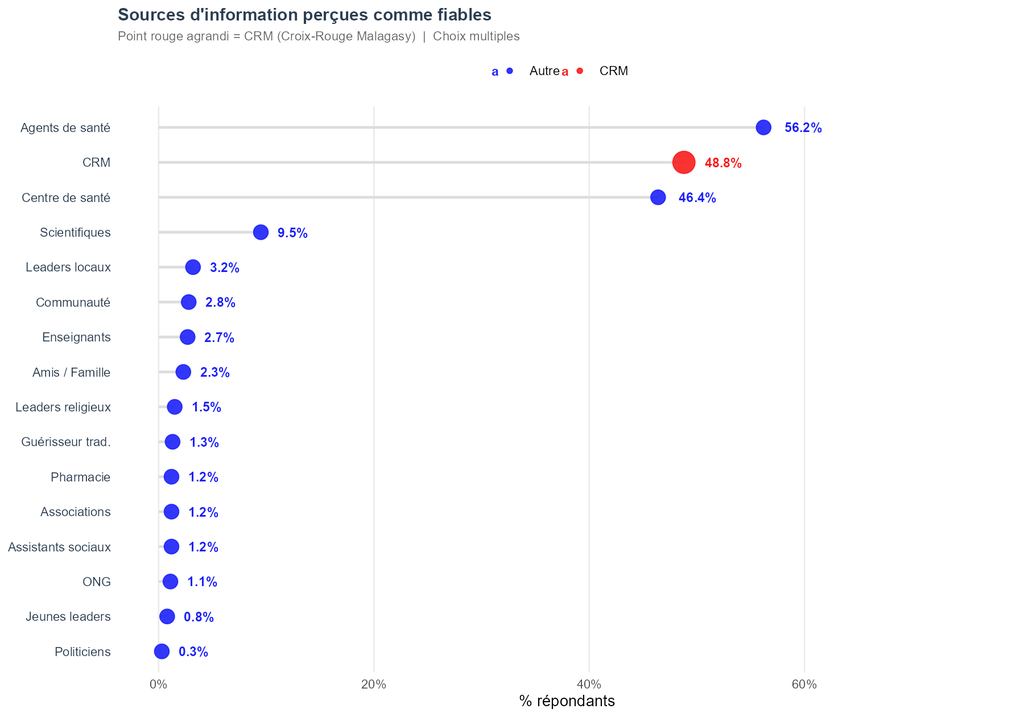

⬇️ Télécharger PNG

**Description :** Identifie les sources d’information considérées comme fiables et crédibles par les répondants (agents de santé, CRM, gouvernement, etc.).

**Interprétation :** La CRM figure-t-elle parmi les sources de confiance ? C’est un indicateur de crédibilité de l’organisation. Les partenaires moins fiables nécessitent un renforcement de capacités ou une meilleure communication.

## 4.3 D5. Langue souhaitée pour l’information

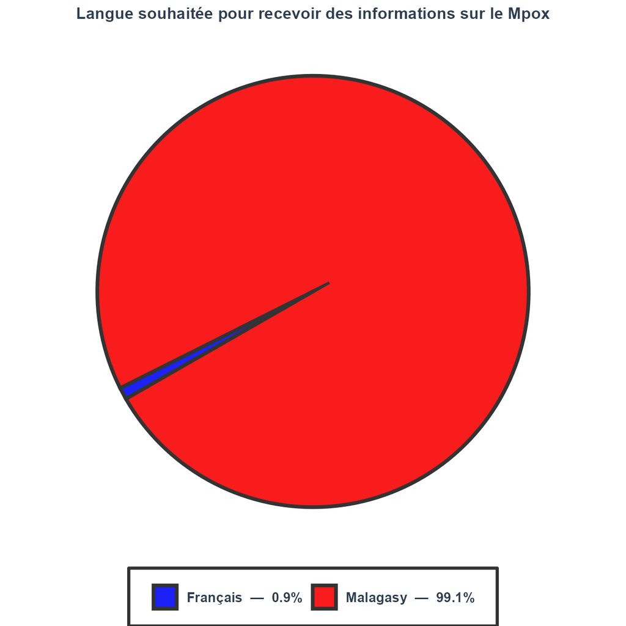

⬇️ Télécharger PNG

**Description :** Préférence linguistique des répondants pour recevoir les informations (français vs malagasy). Important pour l’adaptation des messages.

**Interprétation :** Un taux élevé en malagasy indique l’importance de produire des matériels en langue locale pour assurer la compréhension et l’adoption des messages de prévention.

# 5 SECTION E — VACCINATION

## 5.1 E1. Connaissance du vaccin Mpox

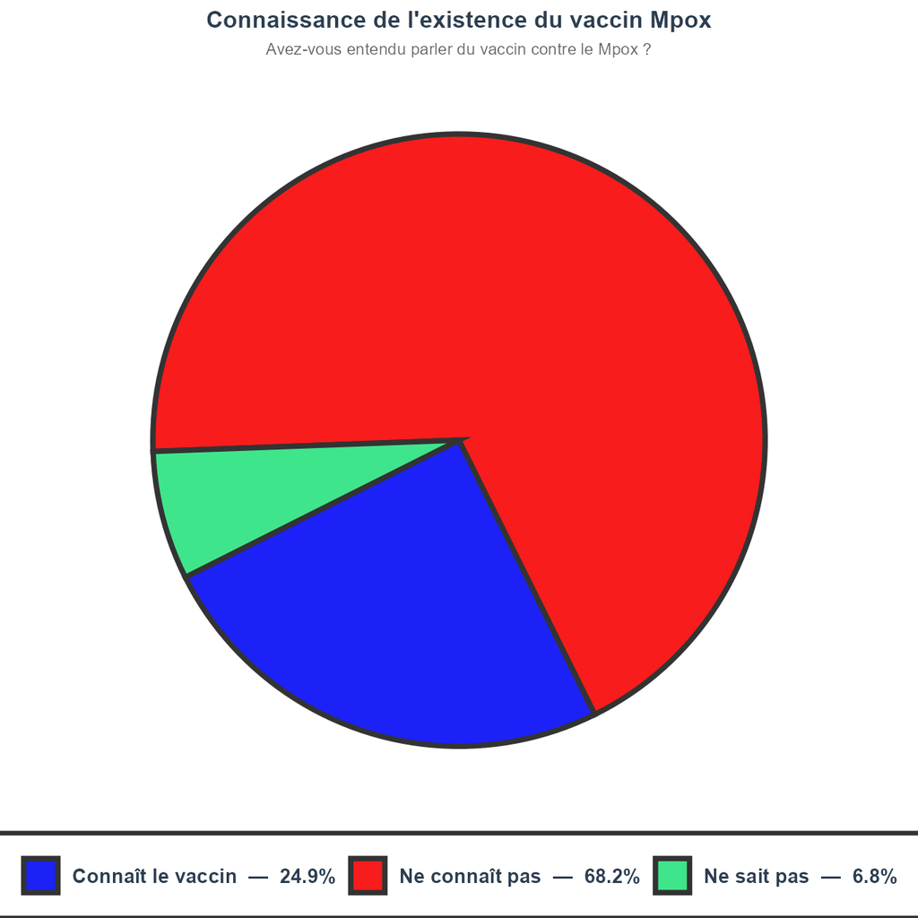

⬇️ Télécharger PNG

**Interprétation :** Le faible taux de connaissance du vaccin nécessite une intensification des campagnes d’information, notamment auprès des groupes vulnérables.

## 5.2 E2. Intention de vaccination

# 6 SECTION F — DISCRIMINATION ET STIGMATISATION

## 6.2 G3. Groupes perçus comme victimes de discrimination (autres sources)

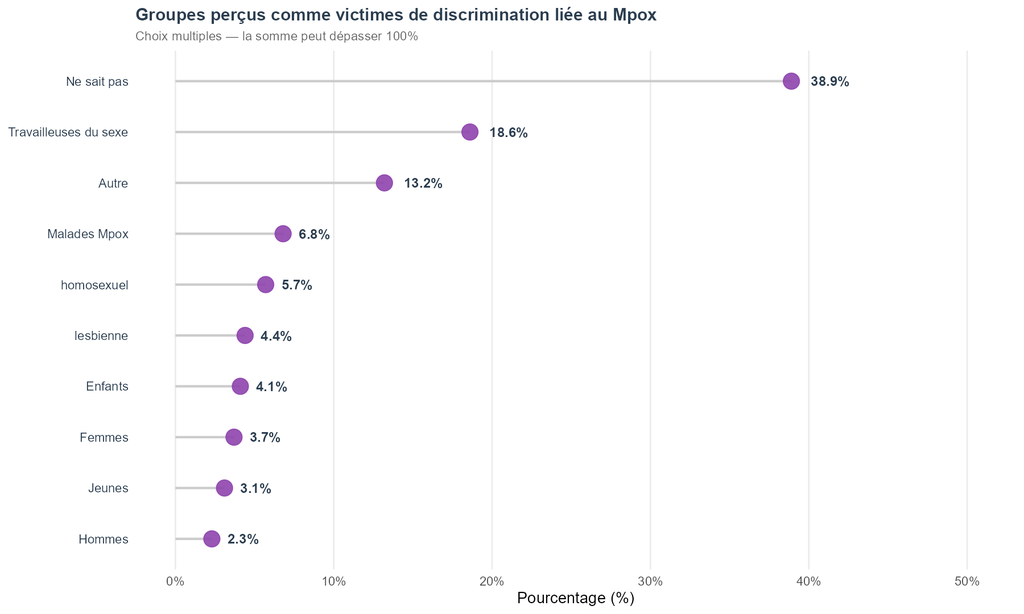

⬇️ Télécharger PNG

**Description :** Groupes supplémentaires identifiés par d’autres sources ou répondants comme victimes de discrimination liée au Mpox.

**Interprétation :** Complète la vue d’ensemble des groupes vulnérables et oriente les actions de plaidoyer et de protection.

## 6.3 G4. Solutions proposées pour réduire la stigmatisation

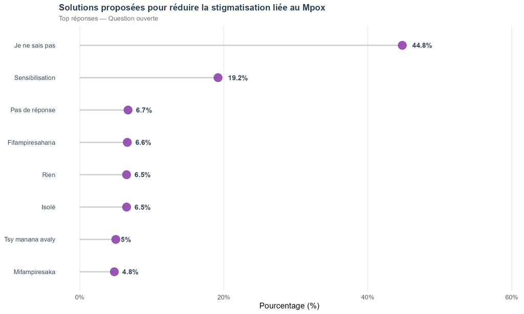

⬇️ Télécharger PNG

**Description :** Solutions proposées par les répondants pour réduire la stigmatisation (sensibilisation, isolement, isolation sociale, etc.).

**Interprétation :** Reflète la compréhension communautaire des causes de la stigmatisation et les actions perçues comme efficaces pour la combattre. Essentiel pour co-concevoir les interventions.

# 7 SECTION H — ENGAGEMENT COMMUNAUTAIRE

## 7.1 H1. Acteurs représentant la communauté

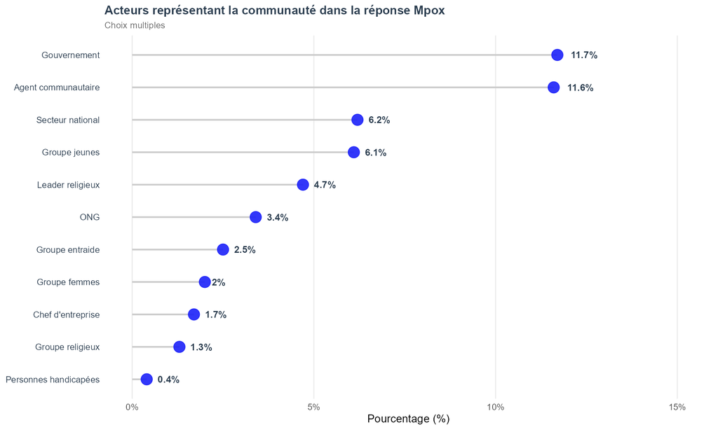

⬇️ Télécharger PNG

**Description :** Acteurs ou structures identifiés comme représentants de la communauté dans la réponse au Mpox (leaders communautaires, agents de santé, ONG, gouvernement, etc.).

**Interprétation :** Identifie les canaux privilégiés de communication et de mobilisation communautaire. Oriente le partenariat et le renforcement des capacités.

## 7.2 H2. Avis consulté par les autorités

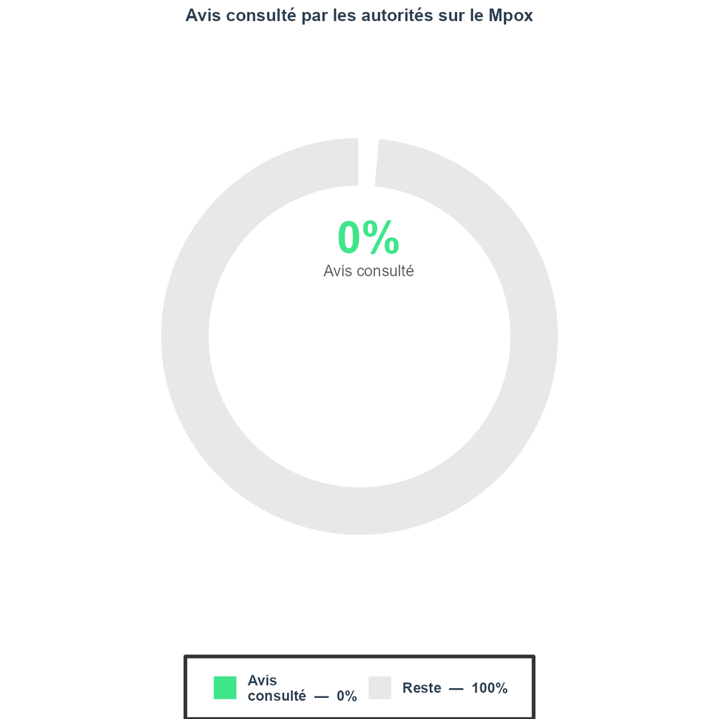

⬇️ Télécharger PNG

**Description :** Proportion de répondants ayant été consultés par les autorités (gouvernement, santé, administration) sur la réponse au Mpox.

**Interprétation :** Mesure le degré d’inclusion des communautés dans la prise de décision. Un taux élevé indique une gouvernance participative et renforcée.

## 7.3 H3. Connaissance d’un mécanisme de feedback

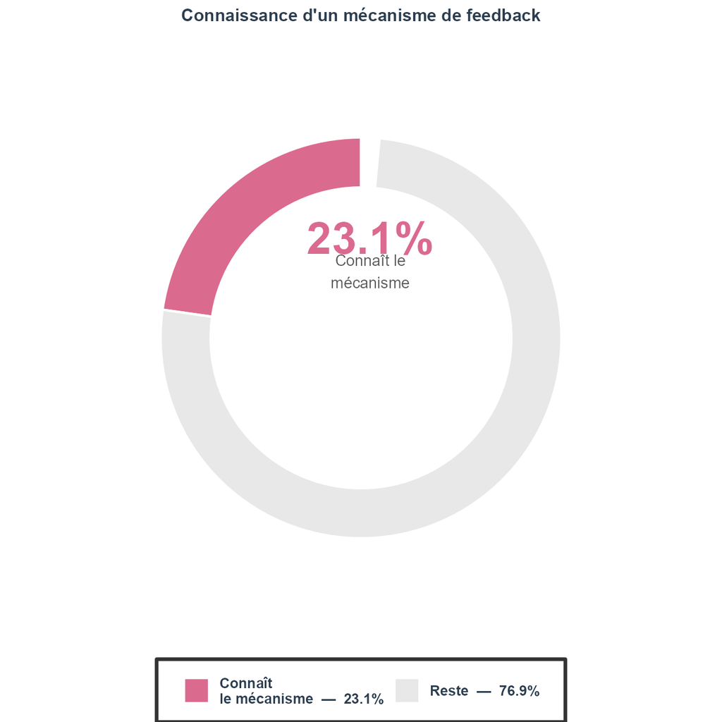

⬇️ Télécharger PNG

**Description :** Proportion de répondants connaissant l’existence d’un mécanisme pour fournir des retours, des plaintes ou des suggestions aux autorités sanitaires.

**Interprétation :** Un faible taux indique le besoin de mieux promouvoir les canaux de rétroaction et d’assurer leur accessibilité.

## 7.4 H4. Canaux préférés pour le feedback

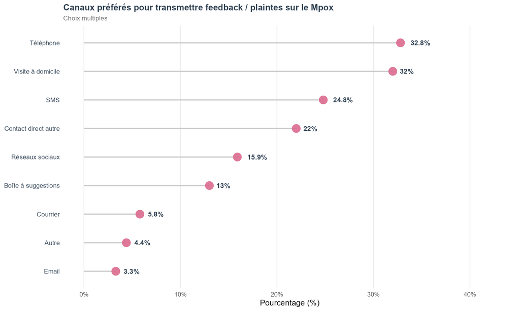

⬇️ Télécharger PNG

**Description :** Canaux préférés par les répondants pour transmettre feedback, plaintes ou suggestions (téléphone, visite à domicile, email, SMS, etc.).

**Interprétation :** Oriente la mise en place et la promotion des mécanismes de feedback. Les canaux les plus accessibles doivent être priorisés.

## 7.5 H5. Acteurs de confiance pour l’engagement communautaire

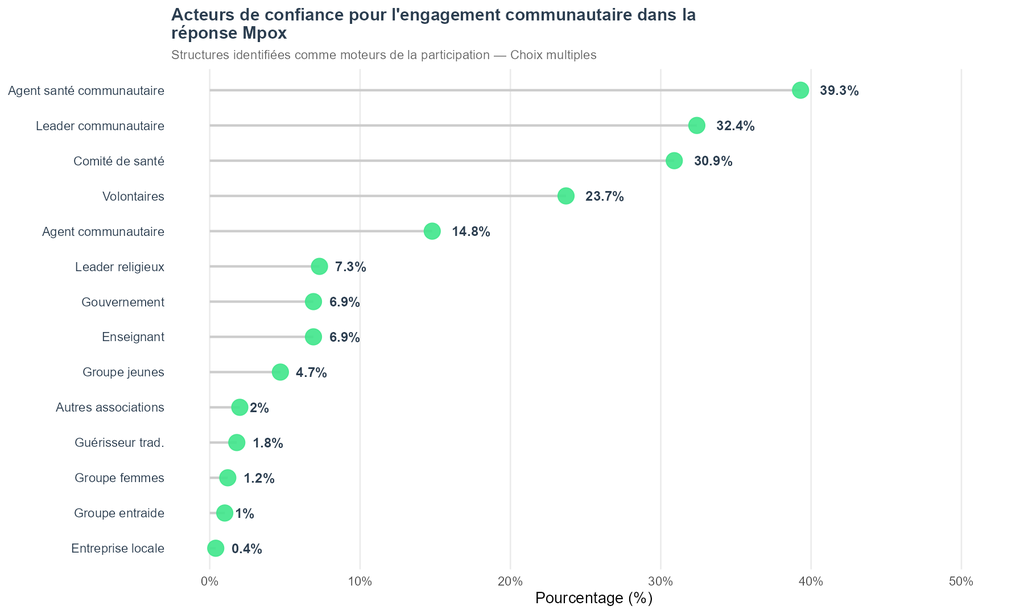

⬇️ Télécharger PNG

**Description :** Structures ou acteurs de confiance pour impulser la participation communautaire dans la réponse au Mpox (agents de santé, leaders, comités, etc.).

**Interprétation :** La confiance est essentielle pour l’engagement. Les acteurs de confiance identifiés doivent être renforcés et impliqués dans tous les niveaux de la réponse.

Avotra — Database Manager

Croix-Rouge Malagasy

Rapport généré le 11 mai 2026

Tous les graphiques sont téléchargeables en PNG pour présentation ou publication.